# Lesson 5: Coding and Financial Analysis

## Setup

```python
llm_config = {"model": "gpt-4-turbo"}
```

## Define a code executor

```python
from autogen.coding import LocalCommandLineCodeExecutor
```

```python
executor = LocalCommandLineCodeExecutor(
    timeout=60, #seconds
    work_dir="coding", # all code be generated can be found in that folder
)
```

## Create agents

```python
from autogen import ConversableAgent, AssistantAgent
```

### 1. Agent with code executor configuration

```python
code_executor_agent = ConversableAgent(
    name="code_executor_agent",
    llm_config=False,
    code_execution_config={"executor": executor},
    human_input_mode="ALWAYS",
    # if agent doesn't find code, reply following
    default_auto_reply=
    "Please continue. If everything is done, reply 'TERMINATE'.",
)
```

### 2. Agent with code writing capability

```python
# only propose code but not execute
code_writer_agent = AssistantAgent(
    name="code_writer_agent",
    llm_config=llm_config,
    code_execution_config=False,
    human_input_mode="NEVER",
)
```

```python
code_writer_agent_system_message = code_writer_agent.system_message
```

```python
print(code_writer_agent_system_message)
```

```
You are a helpful AI assistant.
Solve tasks using your coding and language skills.
In the following cases, suggest python code (in a python coding block) or shell script (in a sh coding block) for the user to execute.
    1. When you need to collect info, use the code to output the info you need, for example, browse or search the web, download/read a file, print the content of a webpage or a file, get the current date/time, check the operating system. After sufficient info is printed and the task is ready to be s…
    2. When you need to perform some task with code, use the code to perform the task and output the result. Finish the task smartly.
Solve the task step by step if you need to. If a plan is not provided, explain your plan first. Be clear which step uses code, and which step uses your language skill.
When using code, you must indicate the script type in the code block. The user cannot provide any other feedback or perform any other action beyond executing the code you suggest. The user can't modify your code. So do not suggest incomplete code which requires users to modify. Don't use a code bloc…
If you want the user to save the code in a file before executing it, put # filename: <filename> inside the code block as the first line. Don't include multiple code blocks in one response. Do not ask users to copy and paste the result. Instead, use 'print' function for the output when relevant. Chec…
If the result indicates there is an error, fix the error and output the code again. Suggest the full code instead of partial code or code changes. If the error can't be fixed or if the task is not solved even after the code is executed successfully, analyze the problem, revisit your assumption, coll…
When you find an answer, verify the answer carefully. Include verifiable evidence in your response if possible.
Reply "TERMINATE" in the end when everything is done.
```

## The task!

Ask the two agents to collaborate on a stock analysis task.

```python
import datetime

today = datetime.datetime.now().date()
message = f"Today is {today}. "\
"Create a plot showing stock gain YTD for NVDA and TLSA. "\
"Make sure the code is in markdown code block and save the figure"\
" to a file ytd_stock_gains.png."""
```

**Note:** In this lesson, you will use GPT 4 for better results. Please note that the lesson has a quota limit. If you want to explore the code in this lesson further, we recommend trying it locally with your own API key.

**Note**: You might see a different set of outputs than those shown in the video. The agents collaborate to generate the code needed for your task, and they might produce code with errors in the process. However, they will ultimately provide a correct code in the end.

```python
chat_result = code_executor_agent.initiate_chat(
    code_writer_agent,
    message=message,
)
```

````
code_executor_agent (to code_writer_agent):

Today is 2024-06-14. Create a plot showing stock gain YTD for NVDA and TLSA. Make sure the code is in markdown code block and save the figure to a file ytd_stock_gains.png.

--------------------------------------------------------------------------------
code_writer_agent (to code_executor_agent):

To create a plot showing the Year-To-Date (YTD) stock gains for NVIDIA (symbol: NVDA) and Tesla (symbol TSLA as of 2023), we'll perform the following steps:
1. Get the YTD stock prices for NVDA and TSLA.
2. Calculate the percentage gain from the start of the year to the current date.
3. Plot the gains on a graph.
4. Save the graph to a file named "ytd_stock_gains.png".

The required data will be obtained using the `yfinance` library, which allows for easy extraction of stock data. Here's the complete Python code you need to run:

```python
# filename: stock_gain_plot.py
import yfinance as yf
import matplotlib.pyplot as plt
import pandas as pd

# Set the start date to the beginning of the year and the end date to today
start_date = "2024-01-01"
end_date = "2024-06-14"

# Fetch the stock data for NVDA and TSLA
nvda_data = yf.download('NVDA', start=start_date, end=end_date)
tsla_data = yf.download('TSLA', start=start_date, end=end_date)

# Calculate the percentage gain from the first day of the year
nvda_gain = ((nvda_data['Close'] - nvda_data['Close'][0]) / nvda_data['Close'][0]) * 100
tsla_gain = ((tsla_data['Close'] - tsla_data['Close'][0]) / tsla_data['Close'][0]) * 100

# Create a plot
plt.figure(figsize=(10, 5))
plt.plot(nvda_gain, label='NVIDIA', color='green')
plt.plot(tsla_gain, label='Tesla', color='blue')
plt.title('YTD Stock Gain for NVDA and TSLA')
plt.xlabel('Date')
plt.ylabel('Percentage Gain')
plt.legend()
plt.grid(True)

# Save the plot to a file
plt.savefig('ytd_stock_gains.png')
plt.show()
```

### Instructions
1. Copy the entire code above.
2. Save it into a file named `stock_gain_plot.py`.
3. Run the file using your Python environment. This will fetch the necessary data, generate the plot, and save it as `ytd_stock_gains.png`.

The script automatically fetches the latest stock data up to the given date, computes the YTD gains based on closing prices, plots this data clearly, and saves the plot in the desired format.

--------------------------------------------------------------------------------
Provide feedback to code_writer_agent. Press enter to skip and use auto-reply, or type 'exit' to end the conversation: exit
````

## Let's see the plot!

**Note**:

- Your plot might differ from the one shown in the video because the LLM's freestyle code generation could choose a different plot type, such as a bar plot.
- You can re-run the previous cell and check the generated code. If it produces a bar plot, remember you can directly specify your preference by asking for a specific plot type instead of a bar plot.

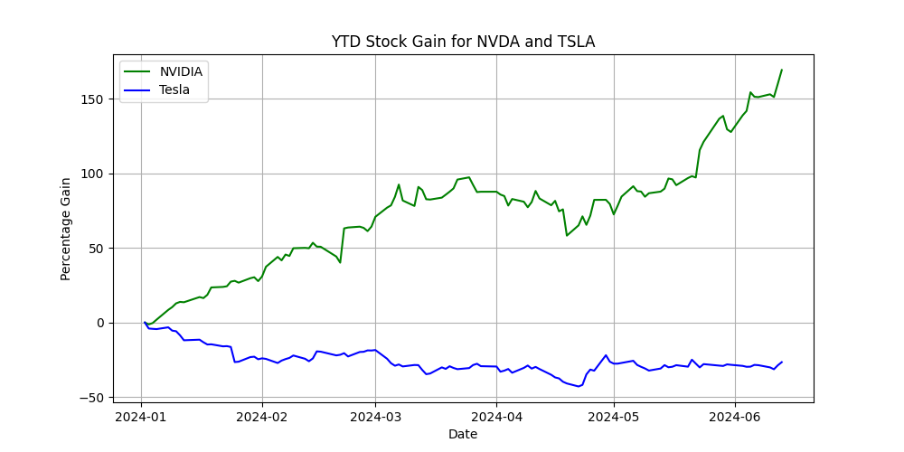

```python
import os
from IPython.display import Image

Image(os.path.join("coding", "ytd_stock_gains.png"))
```

**Note**: The agent will automatically save the code in a .py file and the plot in a .png file. To access and check the files generated by the agents, go to the `File` menu and select `Open....` Then, open the folder named `coding` to find all the generated files.

## User-Defined Functions

Instead of asking LLM to generate the code for downloading stock data and plotting charts each time, you can define functions for these two tasks and have LLM call these functions in the code.

```python
def get_stock_prices(stock_symbols, start_date, end_date):
    """Get the stock prices for the given stock symbols between
    the start and end dates.

    Args:
        stock_symbols (str or list): The stock symbols to get the
        prices for.
        start_date (str): The start date in the format
        'YYYY-MM-DD'.
        end_date (str): The end date in the format 'YYYY-MM-DD'.

    Returns:
        pandas.DataFrame: The stock prices for the given stock
        symbols indexed by date, with one column per stock
        symbol.
    """
    import yfinance

    stock_data = yfinance.download(
        stock_symbols, start=start_date, end=end_date
    )
    return stock_data.get("Close")
```

```python
def plot_stock_prices(stock_prices, filename):
    """Plot the stock prices for the given stock symbols.

    Args:
        stock_prices (pandas.DataFrame): The stock prices for the
        given stock symbols.
    """
    import matplotlib.pyplot as plt

    plt.figure(figsize=(10, 5))
    for column in stock_prices.columns:
        plt.plot(
            stock_prices.index, stock_prices[column], label=column
                )
    plt.title("Stock Prices")
    plt.xlabel("Date")
    plt.ylabel("Price")
    plt.grid(True)
    plt.savefig(filename)
```

### Create a new executor with the user-defined functions

```python
executor = LocalCommandLineCodeExecutor(
    timeout=60,
    work_dir="coding",
    functions=[get_stock_prices, plot_stock_prices],
)
```

```python
code_writer_agent_system_message += executor.format_functions_for_prompt()
print(code_writer_agent_system_message)
```

```
You are a helpful AI assistant.
Solve tasks using your coding and language skills.
In the following cases, suggest python code (in a python coding block) or shell script (in a sh coding block) for the user to execute.
    1. When you need to collect info, use the code to output the info you need, for example, browse or search the web, download/read a file, print the content of a webpage or a file, get the current date/time, check the operating system. After sufficient info is printed and the task is ready to be s…
    2. When you need to perform some task with code, use the code to perform the task and output the result. Finish the task smartly.
Solve the task step by step if you need to. If a plan is not provided, explain your plan first. Be clear which step uses code, and which step uses your language skill.
When using code, you must indicate the script type in the code block. The user cannot provide any other feedback or perform any other action beyond executing the code you suggest. The user can't modify your code. So do not suggest incomplete code which requires users to modify. Don't use a code bloc…
If you want the user to save the code in a file before executing it, put # filename: <filename> inside the code block as the first line. Don't include multiple code blocks in one response. Do not ask users to copy and paste the result. Instead, use 'print' function for the output when relevant. Chec…
If the result indicates there is an error, fix the error and output the code again. Suggest the full code instead of partial code or code changes. If the error can't be fixed or if the task is not solved even after the code is executed successfully, analyze the problem, revisit your assumption, coll…
When you find an answer, verify the answer carefully. Include verifiable evidence in your response if possible.
Reply "TERMINATE" in the end when everything is done.
    You have access to the following user defined functions. They can be accessed from the module called `functions` by their function names.

For example, if there was a function called `foo` you could import it by writing `from functions import foo`

def get_stock_prices(stock_symbols, start_date, end_date):
    """Get the stock prices for the given stock symbols between
        the start and end dates.

        Args:
            stock_symbols (str or list): The stock symbols to get the
            prices for.
            start_date (str): The start date in the format
            'YYYY-MM-DD'.
            end_date (str): The end date in the format 'YYYY-MM-DD'.

        Returns:
            pandas.DataFrame: The stock prices for the given stock
            symbols indexed by date, with one column per stock
            symbol.
    """
    ...

def plot_stock_prices(stock_prices, filename):
    """Plot the stock prices for the given stock symbols.

        Args:
            stock_prices (pandas.DataFrame): The stock prices for the
            given stock symbols.
    """
    ...
```

### Let's update the agents with the new system message

```python
code_writer_agent = ConversableAgent(
    name="code_writer_agent",
    system_message=code_writer_agent_system_message,
    llm_config=llm_config,
    code_execution_config=False,
    human_input_mode="NEVER",
)
```

```python
code_executor_agent = ConversableAgent(
    name="code_executor_agent",
    llm_config=False,
    code_execution_config={"executor": executor},
    human_input_mode="ALWAYS",
    default_auto_reply=
    "Please continue. If everything is done, reply 'TERMINATE'.",
)
```

### Start the same task again!

```python
chat_result = code_executor_agent.initiate_chat(
    code_writer_agent,
    message=f"Today is {today}."
    "Download the stock prices YTD for NVDA and TSLA and create"
    "a plot. Make sure the code is in markdown code block and "
    "save the figure to a file stock_prices_YTD_plot.png.",
)
```

````
code_executor_agent (to code_writer_agent):

Today is 2024-06-14.Download the stock prices YTD for NVDA and TSLA and createa plot. Make sure the code is in markdown code block and save the figure to a file stock_prices_YTD_plot.png.

--------------------------------------------------------------------------------
code_writer_agent (to code_executor_agent):

First, we need to check the system date to verify whether it is indeed 2024-06-14 as stated. Let's get the current date:

```python
# filename: check_date.py
import datetime

# Print current date
print("Current system date:", datetime.datetime.now().date())
```

Please run the above Python script to confirm today's date. If the date is validated as 2024-06-14, we can proceed with fetching and plotting the stock prices for NVDA and TSLA from the beginning of this year, 2024-01-01, until today.

--------------------------------------------------------------------------------
Provide feedback to code_writer_agent. Press enter to skip and use auto-reply, or type 'exit' to end the conversation:

>>>>>>>> NO HUMAN INPUT RECEIVED.

>>>>>>>> USING AUTO REPLY...

>>>>>>>> EXECUTING CODE BLOCK (inferred language is python)...
code_executor_agent (to code_writer_agent):

exitcode: 0 (execution succeeded)
Code output: Current system date: 2024-06-14


--------------------------------------------------------------------------------
code_writer_agent (to code_executor_agent):

Thank you for confirming the date. We will proceed with downloading the Year-To-Date (YTD) stock prices for NVIDIA (NVDA) and Tesla (TSLA) and then create a plot saved as a PNG file.

Here is the Python code to perform these tasks:

````

[output cut: 9 more lines]

````

# Fetch the stock prices
stock_prices = get_stock_prices(stock_symbols, start_date, end_date)

# Plot the stock prices and save to file
plot_stock_prices(stock_prices, 'stock_prices_YTD_plot.png')

# Notify the user that the process is complete and the file is saved
print("Stock price plot saved as 'stock_cssprices_YTD_plot.png'.")
```

Please execute the script provided. It will download the required stock data and save the plot of stock prices as 'stock_prices_YTD_plot.png'. This file will be created in the current directory from where the script is run.

--------------------------------------------------------------------------------
Provide feedback to code_writer_agent. Press enter to skip and use auto-reply, or type 'exit' to end the conversation: exit
````

### Plot the results

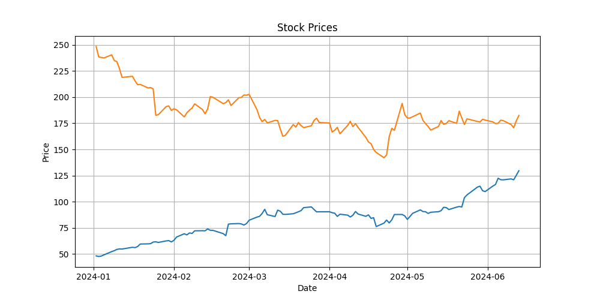

```python
Image(os.path.join("coding", "stock_prices_YTD_plot.png"))
```

**Note**: The agent will automatically save the code in a .py file and the plot in a .png file. To access and check the files generated by the agents, go to the `File` menu and select `Open....` Then, open the folder named `coding` to find all the generated files.